# Low level handling of sf objects

You can handle sf objects at a low level but it can take a bit of getting used to

```r
knitr::opts_chunk$set(error = TRUE, message = TRUE)
```

## Packages

Everything here needs just `sf` and `dplyr`.

```r
library(sf)
library(dplyr)
```

## Making polygons

My main confusion dealing with polygons in `sf` sounds dumb, but was easily fixed. Matrices in *R* get populated by column, by default, where we typically think of the points in a polygon as being specified as rows of x-y coordinate values. There’s also the slightly strange fact that you have to wrap a matrix of points in a list to make a polygon. So because of the row-column thing, there’s a tendency to do

```r
mat <- matrix(c(0, 0,
                1, 0,
                1, 1,
                0, 1,
                0, 0), nrow = 5, ncol = 2)
square <- st_polygon(list(mat))
```

```
Error in MtrxSet(x, dim, type = "POLYGON", needClosed = TRUE): polygons not (all) closed
```

But that fails, because the matrix we made was

```r
mat
```

[output not shown]

and the first and last rows don’t match.

But specify that the matrix should be populated `byrow` and all is well

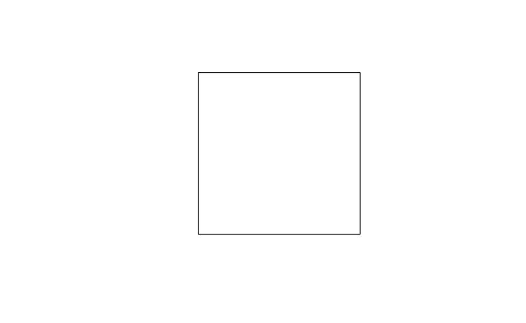

```r
square <- st_polygon(list(matrix(c(0, 0,
                                   1, 0,
                                   1, 1,
                                   0, 1,
                                   0, 0), nrow = 5, ncol = 2, byrow = TRUE)))
plot(square)
```

If you happen to have vectors of the x and y coordinates, then it’s easier.

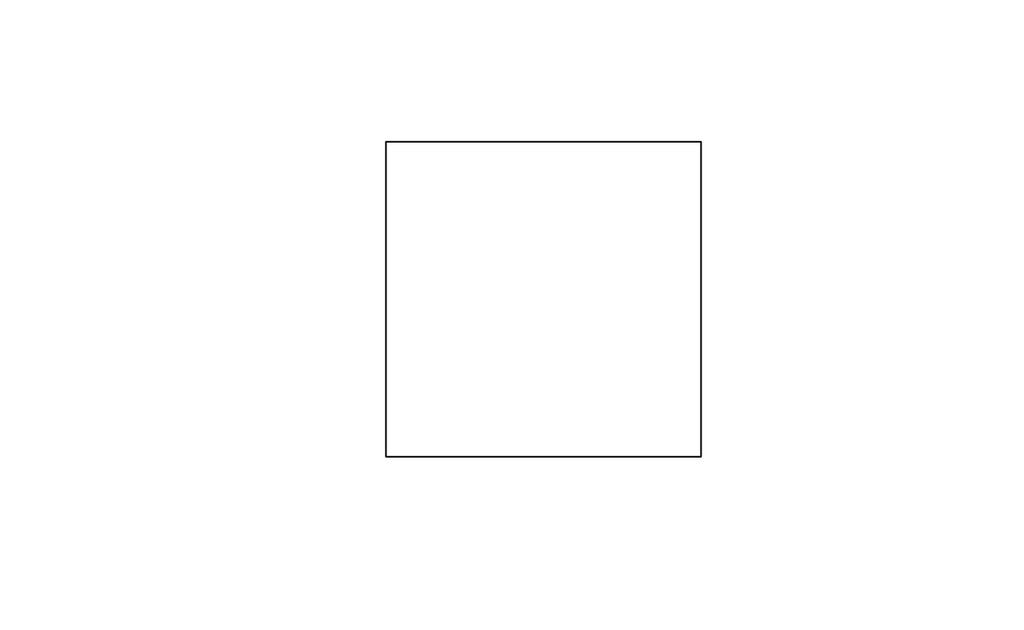

```r
x <- c(0, 1, 1, 0, 0)
y <- c(0, 0, 1, 1, 0)
square <- st_polygon(list(matrix(c(x, y), nrow = 5, ncol = 2)))
plot(square)
```

## Floating point coordinates and their discontents

`sf` defaults to using floating point calculations which has some annoying side-effects. For example, the code below results in an error

```r
angles <- 0:3 * 2 * pi / 3
x <- cos(angles)
y <- sin(angles)
triangle <- st_polygon(list(matrix(c(x, y), nrow = 7, ncol = 2)))
```

[output not shown]

Because `sf` defaults to floating point it doesn’t consider the polygon closed due to precision issues that mean *R* considers `sin(0) != sin(2 * pi)`:

```r
sin(0) == sin(2 * pi)
```

```
[1] FALSE
```

There is no easy way to fix this except to round the coordinates!

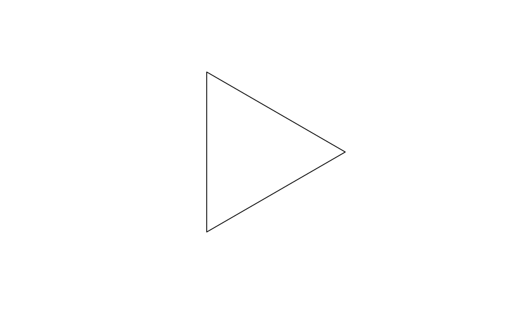

```r
x <- round(x, 6)
y <- round(y, 6)
triangle <- st_polygon(list(matrix(c(x, y), nrow = 4, ncol = 2)))
plot(triangle)
```

There’s not a lot you can do about this when you are constructing `sf` objects. Polygons must be closed, and equality is strictly applied to the opening and closing points. You can’t ask `st_polygon` to automatically close polygons for you.

Once you have polygons to work with, the problem can come back to bite you, but there is a way around it. For example, this works OK:

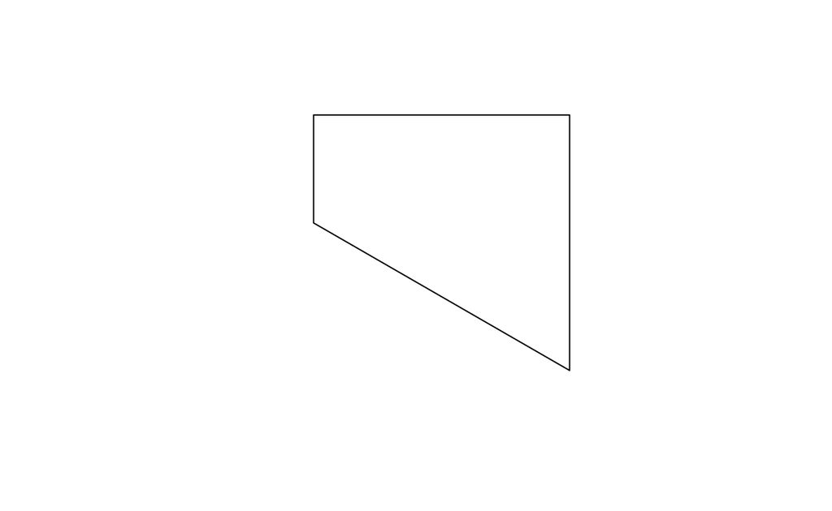

```r
square %>%
  st_difference(triangle) %>%
  plot()
```

But let’s make two squares that are *theoretically* adjacent to one another, but happen to have non-integer coordinates (which… is pretty commonplace!)

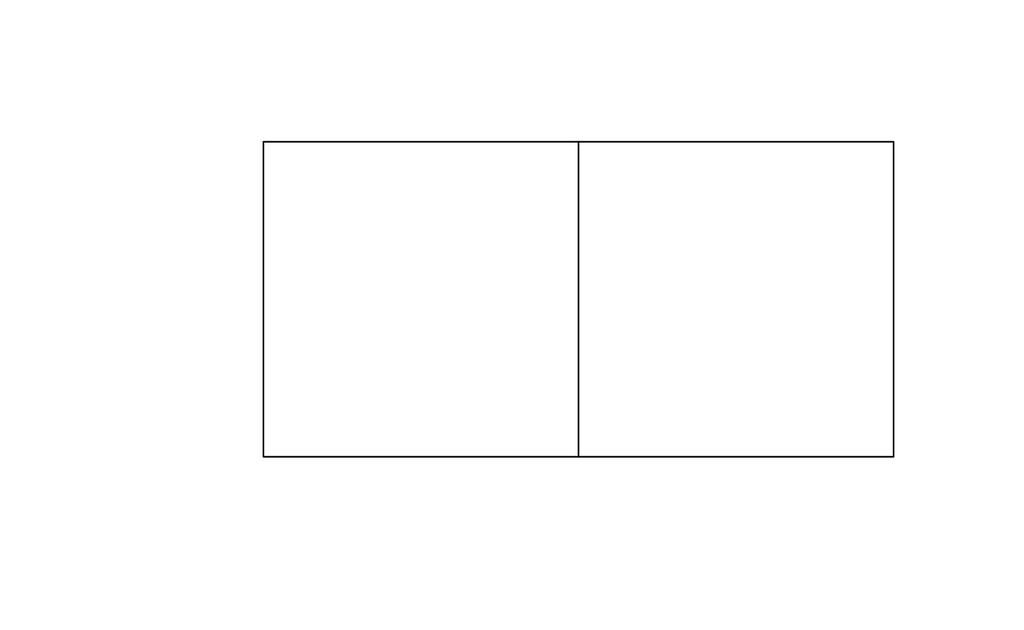

```r
angles <- seq(1, 7, 2) * 2 * pi / 8
angles <- c(angles, angles[1])
x1 <- cos(angles)
y1 <- sin(angles)

s1 <- st_polygon(list(matrix(c(x1, y1), nrow = 5, ncol = 2)))
bb <- st_bbox(s1)
s2 <- s1 + c(bb$xmax - bb$xmin, 0)

plot(s1, xlim = c(-1, 2.1))
plot(s2, add = TRUE)
```

Two squares, next to one another as we might hope, but if, for example, we `st_union` them we get a MULTIPOLYGON.

```r
s3 <- st_union(s1, s2)
s3
```

```
MULTIPOLYGON (((0.7071068 0.7071068, -0.7071068 0.7071068, -0.7071068 -0.7071068, 0.7071068 -0.7071068, 0.7071068 0.7071068)), ((2.12132 0.7071068, 0.7071068 0.7071068, 0.7071068 -0.7071068, 2.12132 -0.7071068, 2.12132 0.7071068)))
```

If we plot them, they still appear separate

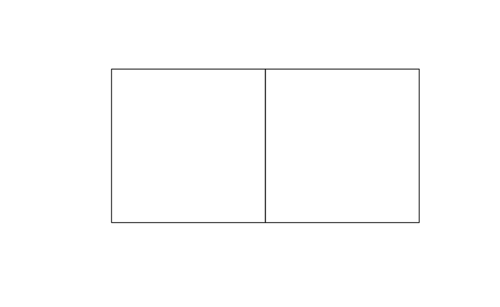

```r
plot(s3)
```

and if we measure the distance between them, turns out they don’t touch at all, but are in fact a miniscule distance apart…

```r
s1 %>% st_distance(s2)
```

```
             [,1]
[1,] 3.330669e-16
```

It’s probably not necessary to point out how silly this is, even if it is strictly correct.

[figure not shown]

```
[1] "https://imgs.xkcd.com/comics/coordinate_precision.png"
```

```r
RXKCD::getXKCD(2170)$img
```

## Specifying precision for spatial operations

By contrast if we use `rgeos` functions the equivalent union operation works as we might expect (although we do have to feed `rgeos` the old `sp` types of polygon, which we can do via a call to `as("Spatial")`…)

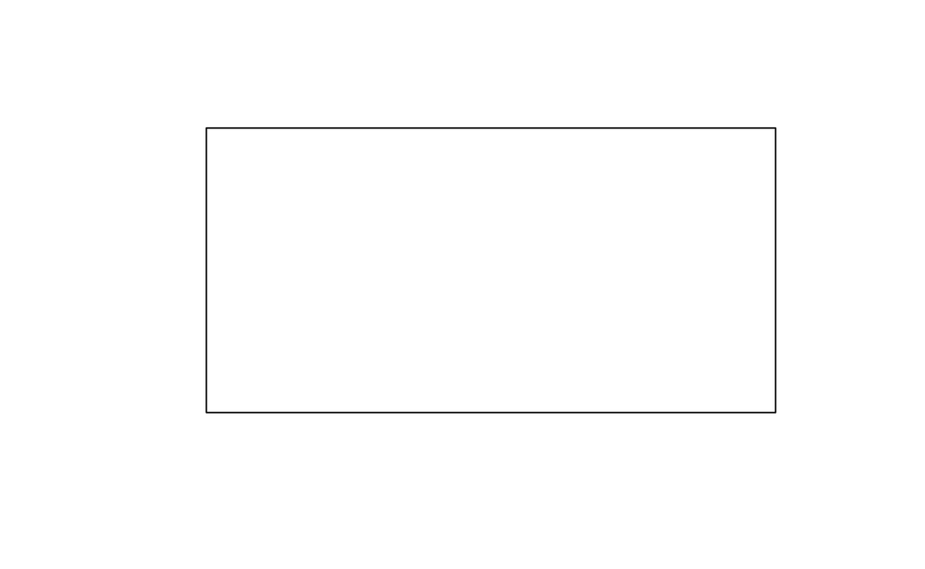

```r
rgeos::gUnion(as(s1, "Spatial"), as(s2, "Spatial")) %>%
  st_as_sfc() %>%
  plot()
```

`sf` does allow us to effectively emulate the `rgeos` behaviour, albeit not for simple geometries. When we instead bundle geometries up into feature collections, we can assign them a precision, and this will take care of the kinds of problems we see above:

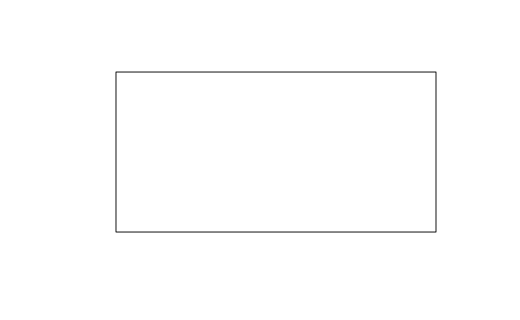

```r
s1_sfc <- st_sfc(s1) %>%
  st_set_precision(1e8)
s2_sfc <- st_sfc(s2) %>%
  st_set_precision(1e8)

s1_sfc %>% st_union(s2_sfc) %>%
  plot()
```

The first time I looked this up [in help](https://r-spatial.github.io/sf/reference/st_precision.html), I got it wrong [due to careless reading](https://github.com/r-spatial/sf/issues/1855), and, I think, assuming that the number you provide to `st_set_precision()` was a ‘tolerance’, or, in effect a ‘snap distance’. The help is also a bit roundabout, and directs you to [this page](https://locationtech.github.io/jts/javadoc/org/locationtech/jts/geom/PrecisionModel.html), for an explanation of how it works.

In effect all coordinates are adjusted by applying a function like this one:

```r
adjust_precision <- function(x, precision) {
  round(x * precision) / precision
}
sqrt(2) %>% adjust_precision(1000)
```

```
[1] 1.414
```

### `st_snap`

Another possible fix for the floating point issue is snapping points to the coordinates of another object before applying operations. So this works, although it is not as clean as the `st_precision` option. On the other hand, it does work on plain geometry objects, not only on those that have bundled up into collections.

```r
s1 %>% st_snap(s2, 1e-8) %>%
  st_union(s2)
```

```
POLYGON ((0.7071068 -0.7071068, -0.7071068 -0.7071068, -0.7071068 0.7071068, 0.7071068 0.7071068, 2.12132 0.7071068, 2.12132 -0.7071068, 0.7071068 -0.7071068))
```